# Introductory Course in Supervised Machine Learning

Fundamentals of Regression Analysis

# Learning Outcomes

At the end of this course, you will be able to,

1. Design a research question and project starting from a real structured data set that adapts knowledge from diverse sources and articulate research questions that can be feasibly interrogated through regression models.
2. Demonstrate knowledge of performing simple and multiple linear regression models in R.
3. Demonstrate ability to choose a good liner model by model comparison.
4. Defend the model significance and interpret the models, impact, and its limitations.

# Why Regression?

Explain why we need regression analysis using life expectancy dataset.

Some more examples…

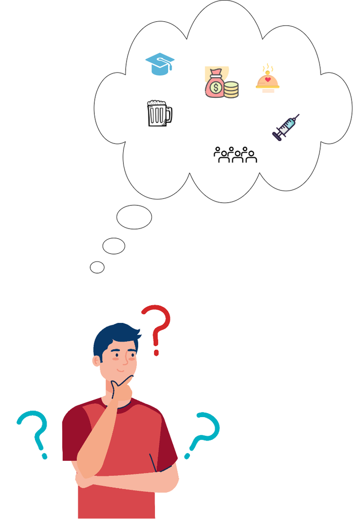

# Formulate Research Questions

Give as an activity…..

## Variable types

cheat sheet for variable types

[figure not shown]

Activity: Drag and drop activity to differentiate among variable types.

## Data Visualization

[figure not shown]

# Data Understanding and Visualization

Here, you will learn about:

1. What are Qualitative and Quantitative variable?
2. How to handle different variable types in R?
3. How to perform data visualization in terms of regression?

### Data Description

The World Health Organization (WHO) keeps track of the health status as well as Immunization related factors, Mortality factors for all countries. Its corresponding economic and social data were collected from United Nation website. This data is taken for the year 2014. Full dataset can be accessed via https://www.kaggle.com/augustus0498/life-expectancy-who.

The variables are:

Life expectancy: Life Expectancy in age

Adult Mortality: Adult Mortality Rates of both sexes (probability of dying between 15 and 60 years per 1000 population)

Infant deaths: Number of Infant Deaths per 1000 population

Alcohol: Alcohol, recorded per capita (15+) consumption (in litres of pure alcohol)

Percentage expenditure: Expenditure on health as a percentage of Gross Domestic Product per capita(%)

Hepatitis B: Hepatitis B (HepB) immunization coverage among 1-year-olds (%)

Measles: Measles - number of reported cases per 1000 population

BMI: Average Body Mass Index of entire population

under-five deaths: Number of under-five deaths per 1000 population

Polio: Polio (Pol3) immunization coverage among 1-year-olds (%)

Total expenditure: General government expenditure on health as a percentage of total government expenditure (%)

Diphtheria: Diphtheria tetanus toxoid and pertussis (DTP3) immunization coverage among 1-year-olds (%)

HIV/AIDS: Deaths per 1 000 live births HIV/AIDS (0-4 years)

GDP: Gross Domestic Product per capita (in USD)

Population: Population of the country

thinness 1-19 years: Prevalence of thinness among children and adolescents for Age 10 to 19 (%)

thinness 5-9 years: Prevalence of thinness among children for Age 5 to 9(%)

Income composition of resources: Human Development Index in terms of income composition of resources (index ranging from 0 to 1)

Schooling: Number of years of Schooling(years)

```r
#load the data
LE = read.csv("Datasets/LifeExpectancy.csv")
attach(LE)
```

```r
head(LE)
```

```
##       country     status life_exp adult_mort inf_death alcohol    perc_exp
## 1   Australia  Developed     82.7          6         1    9.71 10769.36305
## 2     Ireland  Developed     81.2         66         0   10.75   746.36705
## 3 Netherlands  Developed     81.7         58         1    0.01  1491.70360
## 4       Spain  Developed     82.6         58         1    0.01    42.98848
## 5   Argentina Developing     76.2        118         8    7.93   847.37175
## 6      Greece Developing     88.0         73         0    7.53  2163.04341
##   hep_B measles  BMI under_5_d polio tot_exp diphtheria HIV        GDP      pop
## 1    91     340 66.1         1    92    9.42         92 0.1 62214.6912  2346694
## 2    95      33 62.1         0    96    7.78         96 0.1  5553.3262  4617225
## 3    92     140 61.6         1    96    1.90         96 0.1 52157.4687   168658
## 4    96     154 66.0         1    97    9.30         97 0.1   296.4722  4648882
## 5    94       1 62.2         9    92    4.79         94 0.1 12245.2565 42981515
## 6    96       1 66.0         0    99    8.80         99 0.1 21673.7817  1892413
##   thin10_19 thin5_9 Income school
## 1       0.6     0.6  0.936   20.4
## 2       0.3     0.2  0.910   18.6
## 3       1.0     0.9  0.923   18.1
## 4       0.6     0.5  0.877   17.6
## 5       1.0     0.9  0.825   17.3
## 6       0.8     0.7  0.862   17.2
```

```r
str(LE)
```

```
## 'data.frame':    131 obs. of  21 variables:
##  $ country   : chr  "Australia" "Ireland" "Netherlands" "Spain" ...
##  $ status    : chr  "Developed" "Developed" "Developed" "Developed" ...
##  $ life_exp  : num  82.7 81.2 81.7 82.6 76.2 88 89 89 77.3 73.4 ...
##  $ adult_mort: int  6 66 58 58 118 73 69 78 122 169 ...
##  $ inf_death : int  1 0 1 1 8 0 2 0 0 0 ...
##  $ alcohol   : num  9.71 10.75 0.01 0.01 7.93 ...
##  $ perc_exp  : num  10769 746 1492 43 847 ...
##  $ hep_B     : int  91 95 92 96 94 96 88 98 93 94 ...
##  $ measles   : int  340 33 140 154 1 1 443 0 0 11 ...
##  $ BMI       : num  66.1 62.1 61.6 66 62.2 66 61.9 6.9 59.4 61.9 ...
##  $ under_5_d : int  1 0 1 1 9 0 3 0 0 0 ...
##  $ polio     : int  92 96 96 97 92 99 94 98 93 93 ...
##  $ tot_exp   : num  9.42 7.78 1.9 9.3 4.79 8.8 11.3 9.5 6.38 6.55 ...
##  $ diphtheria: int  92 96 96 97 94 99 95 98 93 93 ...
##  $ HIV       : num  0.1 0.1 0.1 0.1 0.1 0.1 0.1 0.1 0.1 0.1 ...
##  $ GDP       : num  62215 5553 52157 296 12245 ...
##  $ pop       : num  2346694 4617225 168658 4648882 42981515 ...
##  $ thin10_19 : num  0.6 0.3 1 0.6 1 0.8 1.1 0.7 1.9 2.6 ...
##  $ thin5_9   : num  0.6 0.2 0.9 0.5 0.9 0.7 1.1 0.5 1.9 2.7 ...
##  $ Income    : num  0.936 0.91 0.923 0.877 0.825 0.862 0.92 0.837 0.86 0.841 ...
##  $ school    : num  20.4 18.6 18.1 17.6 17.3 17.2 17 16.8 16.5 16.5 ...
```

converting as.factor()

```r
LE$country = as.factor(LE$country)
LE$status = as.factor(LE$status)
```

```r
summary(LE)
```

```
##         country           status       life_exp       adult_mort
##  Afghanistan:  1   Developed : 19   Min.   :48.10   Min.   :  2.0
##  Albania    :  1   Developing:112   1st Qu.:64.65   1st Qu.: 74.5
##  Algeria    :  1                    Median :72.00   Median :144.0
##  Angola     :  1                    Mean   :70.52   Mean   :160.4
##  Argentina  :  1                    3rd Qu.:75.80   3rd Qu.:225.0
##  Armenia    :  1                    Max.   :89.00   Max.   :522.0
##  (Other)    :125
##    inf_death         alcohol          perc_exp             hep_B
##  Min.   :  0.00   Min.   : 0.010   Min.   :    0.443   Min.   : 2.00
##  1st Qu.:  0.00   1st Qu.: 0.010   1st Qu.:   48.311   1st Qu.:78.00
##  Median :  3.00   Median : 0.010   Median :  198.734   Median :91.00
##  Mean   : 28.56   Mean   : 3.061   Mean   :  850.874   Mean   :81.71
##  3rd Qu.: 20.00   3rd Qu.: 6.305   3rd Qu.:  718.324   3rd Qu.:96.00
##  Max.   :957.00   Max.   :15.190   Max.   :16255.162   Max.   :99.00
##
##     measles             BMI          under_5_d           polio
##  Min.   :    0.0   Min.   : 2.00   Min.   :   0.00   Min.   : 8.0
##  1st Qu.:    0.0   1st Qu.:22.85   1st Qu.:   1.00   1st Qu.:78.0
##  Median :   10.0   Median :45.90   Median :   3.00   Median :92.0
##  Mean   : 2042.9   Mean   :40.48   Mean   :  38.24   Mean   :83.5
##  3rd Qu.:  289.5   3rd Qu.:59.45   3rd Qu.:  25.50   3rd Qu.:97.0
##  Max.   :79563.0   Max.   :77.10   Max.   :1200.00   Max.   :99.0
##
##     tot_exp         diphtheria         HIV              GDP
##  Min.   : 1.210   Min.   : 2.00   Min.   :0.1000   Min.   :    12.28
##  1st Qu.: 4.485   1st Qu.:80.00   1st Qu.:0.1000   1st Qu.:   554.92
##  Median : 5.820   Median :92.00   Median :0.1000   Median :  2522.80
##  Mean   : 6.107   Mean   :83.89   Mean   :0.8099   Mean   :  7256.85
##  3rd Qu.: 7.630   3rd Qu.:97.00   3rd Qu.:0.5000   3rd Qu.:  7438.05
##  Max.   :13.730   Max.   :99.00   Max.   :9.4000   Max.   :119172.74
##
##       pop              thin10_19         thin5_9           Income
##  Min.   :4.100e+01   Min.   : 0.100   Min.   : 0.100   Min.   :0.3450
##  1st Qu.:2.876e+05   1st Qu.: 1.500   1st Qu.: 1.550   1st Qu.:0.5440
##  Median :1.563e+06   Median : 3.300   Median : 3.500   Median :0.6970
##  Mean   :2.227e+07   Mean   : 4.648   Mean   : 4.886   Mean   :0.6697
##  3rd Qu.:8.059e+06   3rd Qu.: 6.650   3rd Qu.: 6.800   3rd Qu.:0.7790
##  Max.   :1.294e+09   Max.   :26.800   Max.   :27.400   Max.   :0.9360
##
##      school
##  Min.   : 5.30
##  1st Qu.:10.75
##  Median :12.70
##  Mean   :12.68
##  3rd Qu.:14.70
##  Max.   :20.40
##
```

Let’s plot scatter matrix plot to see the relationship among continuous variables. Don’t forget to remove categorical variables.

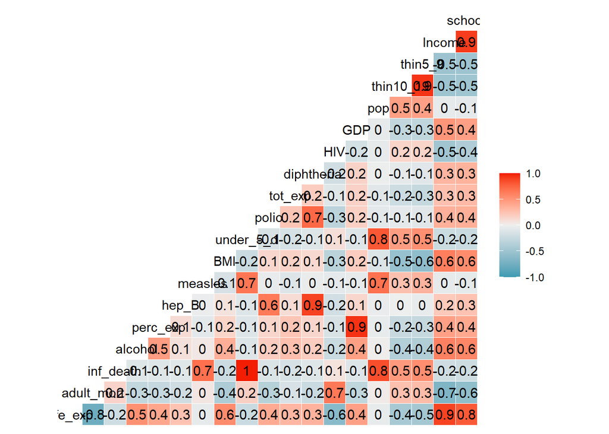

```r
library(GGally)
ggcorr(LE[,-c(1,2)], label = TRUE)
```

Think about what you observe?

Let’s explore the association of development status (factor variable) with life expectancy (response variable).

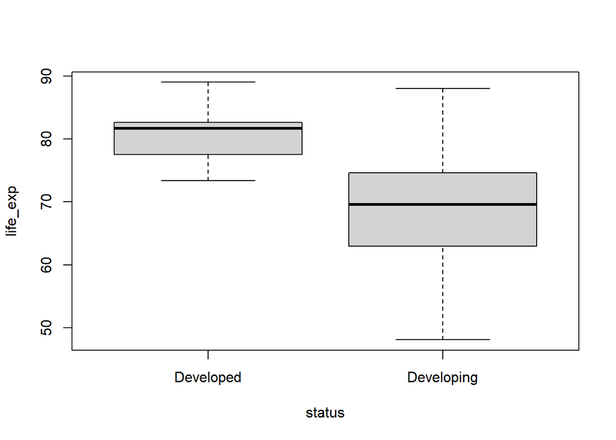

```r
boxplot(life_exp~status)
```

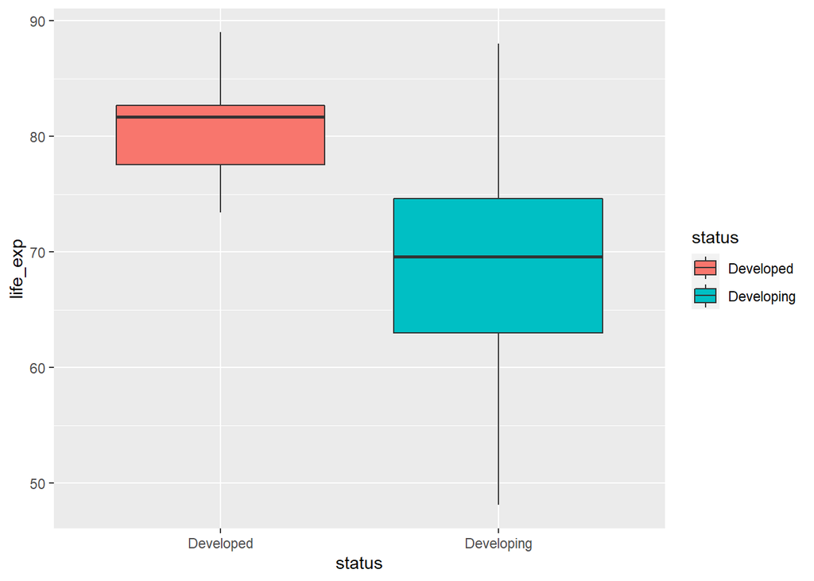

```r
# Alternatively,
library(ggplot2)
ggplot(data = LE,
       aes(x=status, y=life_exp, fill=status))+
        geom_boxplot()
```

# Simple Linear Regression

Here, you will learn about:

1. How to build a simple linear regression model
2. How to assess the significance of linear association
3. What are the model assumptions and how to check whether the model satisfies the assumptions?
4. How to interpret the model?

## Building a Simple Linear Regression

```r
model1 <- lm(formula = life_exp~school, data = LE)
summary(model1)
```

```
##
## Call:
## lm(formula = life_exp ~ school, data = LE)
##
## Residuals:
##      Min       1Q   Median       3Q      Max
## -15.6180  -3.2318   0.5415   3.3678   9.3898
##
## Coefficients:
##             Estimate Std. Error t value Pr(>|t|)
## (Intercept)  38.7198     2.1350   18.14   <2e-16 ***
## school        2.5086     0.1646   15.24   <2e-16 ***
## ---
## Signif. codes:  0 '***' 0.001 '**' 0.01 '*' 0.05 '.' 0.1 ' ' 1
##
## Residual standard error: 5.162 on 129 degrees of freedom
## Multiple R-squared:  0.6429, Adjusted R-squared:  0.6401
## F-statistic: 232.2 on 1 and 129 DF,  p-value: < 2.2e-16
```

## Assessing the significance of linear association (beta values)

First we are interesting in checking whether the linear relationship between life expectancy and school significantly differ from “0”. This can be done by using hypothesis testing with null and alternative hypothesis as follows:

$H_0 : \beta_1 = 0$ suggesting no significant linear relationship between life expectancy (*response variable*) and school (*predictor variable of interest*).

$H_1 : \beta_1 \neq 0$ suggesting significant linear relationship between life expectancy (*response variable*) and school (*predictor variable of interest*).

We can see from the above output that the p-value corresponding to school in the coefficients table is less than 0.05. Thus, we can reject the null hypothesis at 5% level of significance. This suggests the presence of a significant linear relationship between life expectancy (*response variable*) and school (*predictor variable of interest*).

Note that the above model has $R^2 =$ 0.64. That is, about 64.29% of the variation in the data is explained by the model.

## Checking for model assumptions

Next, lets check

1. whether model assumptions (linearity, normality of residuals, homoscedasticity of the residuals) are satisfied.

2.presence of any influential points.

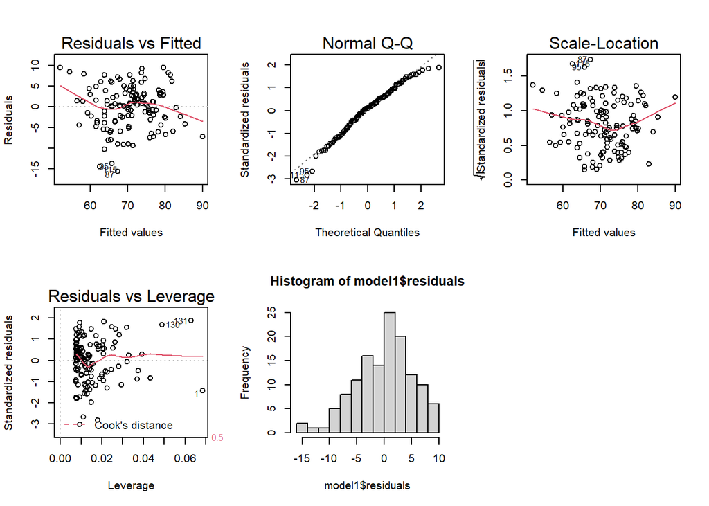

```r
par(mfrow=c(2,3))
plot(model1)
hist(model1$residuals)
```

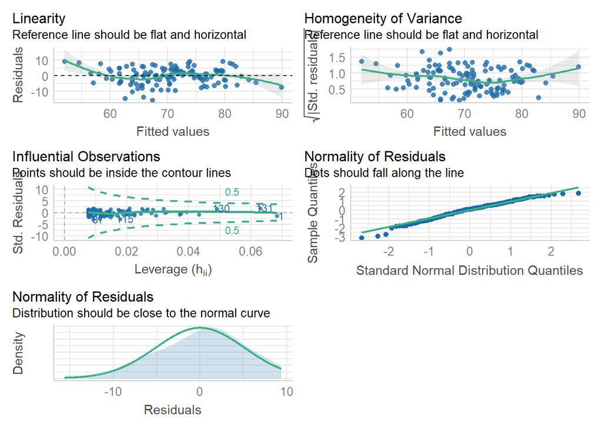

```r
library(performance)
library(see)
check_model(model1)
```

Note that,

- If the model is linear plot 1 should look like the sky at night, with no pattern of any sort.
- In plot 2 line should be straight if the normality assumption of the residuals is valid.
- The third graph is good for detecting non-constancy of variance (heteroscedasticity).
- The fourth graph shows any possible patterns in the standardized residuals as a function of the leverage. The graph also shows Cook’s distance ( a statistic that measures the relative influence of each observation when performing regression analysis), highlighting the identity of particularly influential data points.

NOTE: When data points are singled out as being influential, and When we were happier with other aspects of the model, we would repeat the modelling,leaving out each of these points in turn.

What can we do to address this? (…)

## Interpreting the model

The model equation can be written as:

$\hat Life.exp =$ 38.7198273 + 2.5086129 $School$

(OR)

$E[ \hat Life.exp] =$ 38.7198273 + 2.5086129 $School$

Here,

- the intercept = 38.7198273 meaning that on average the life expectancy is 38.7198273 when the number of years of schooling is 0.
- the slope = 2.5086129 meaning that on average the life expectancy increases by 2.5086129 for every unit increase in school.

Let’s visualize the regression line…

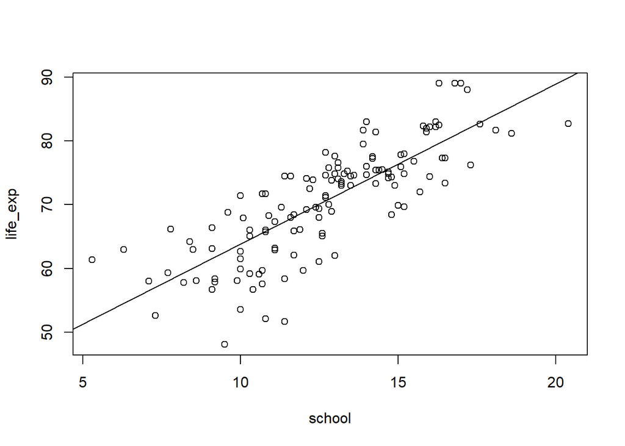

```r
plot(life_exp~school)
abline(model1)
```

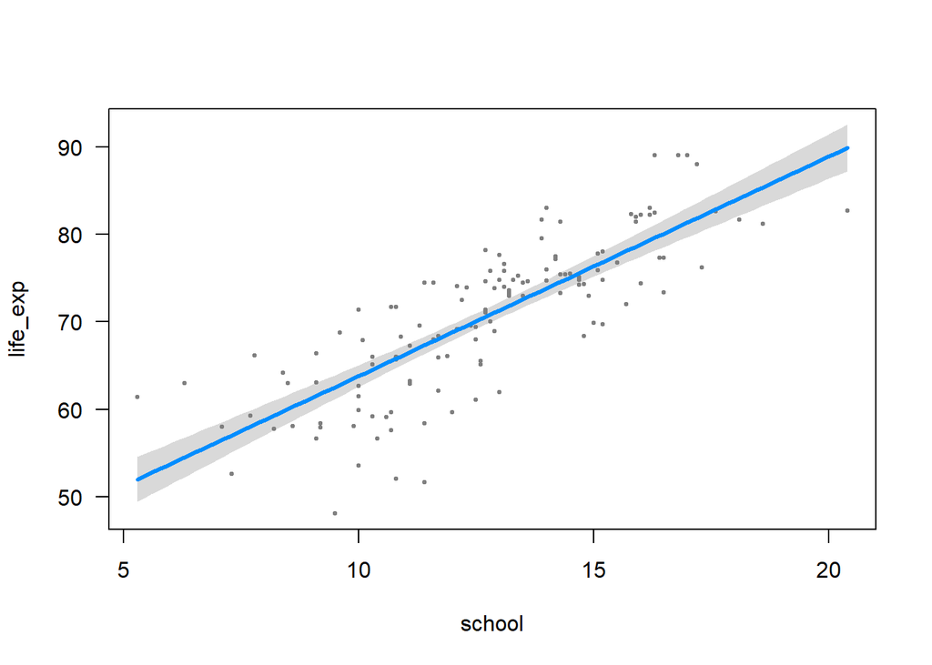

```r
library(visreg)
visreg(model1)
```

# Multiple Linear Regression

Here, you will learn about:

1. How to build a multiple linear regression model
2. How to assess the significance of linear association
3. How to perform ANOVA on a regression output
4. What are the model assumptions and how to check whether the model satisfies the assumptions?
5. How to interpret the model?
6. How to improve the model? (Variable selection, Interaction effects and variable transformations)
7. Pitfalls